# Regression and Prediction

Rafael A. Irizarry  
October 2, 2012

### Money Ball

In 2002 the Yankees $125,928,583 payroll more than tripled the Oakland A's $39,679,746

### Traditional Statistics

[Traditional Statistics](http://mlb.mlb.com/stats/league_leaders.jsp)

### Sabermetrics

[figure not shown]

### Baseball Basics

[figure not shown]

Examples: [success](https://www.youtube.com/watch?v=HL-XjMCPfio) and [failure](https://www.youtube.com/watch?v=NeloljCx-1g)

### Different successful Plate Appearances

- Bases on balls (BB) - the pitcher does not pitch well so you got to first base.
- Single - You hit the ball and get to first base.
- Double (X2B) - You hit the ball and get to second base
- Triple (X3B) - You hit the ball and get to third base
- Home Run (HR) - You hit the ball and go home and score a run. [Here](https://www.youtube.com/watch?v=xYxSZJ9GZ-w) is an example.

Stolen Bases are also considered important. [Here](https://www.youtube.com/watch?v=JSE5kfxkzfk) is a stolen base.

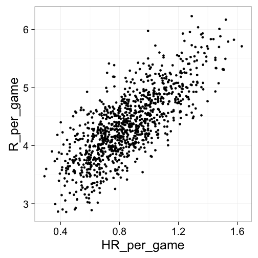

### Bases on Balls or Stolen Bases

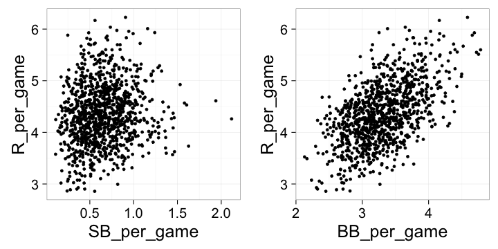

### Confounding with HR

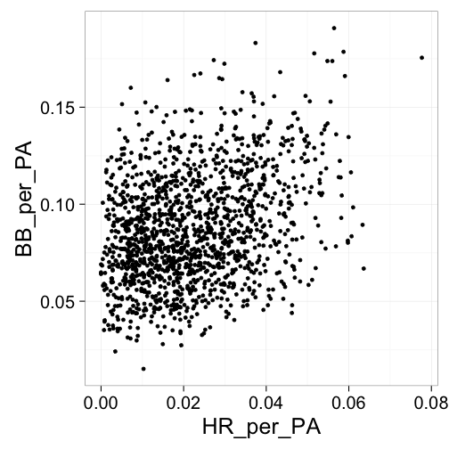

Linear regression will help us parse all this out and help us determine what players to recruit.

### Galton Study of Heredity

Summarize father and son heights

```
  mean(fheight) sd(fheight)
1            68         2.7
```

```
  mean(sheight) sd(sheight)
1            69         2.8
```

We are missing an important summary.

### Correlation

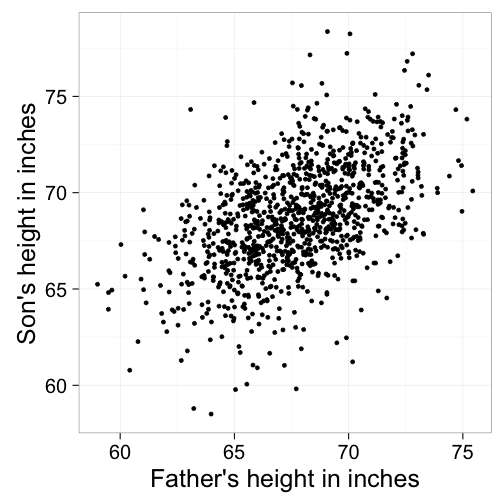

### Correlation

The correlation of a list of pairs \( (x_1, y_1), \dots , (x_n, y_n) \) is defined as

\[ \rho = \frac{1}{n} \sum_{i=1}^n \left( \frac{x_i-\mu_x}{\sigma_x} \right)\left( \frac{y_i-\mu_y}{\sigma_y} \right) \]

For father and son heights we have:

```r
father.son %>% summarize(cor(fheight, sheight))
```

```
  cor(fheight, sheight)
1                   0.5
```

### Correlation is between -1 and 1

To see this

\[ \rho = \frac{1}{n} \sum_{i=1}^n \left( \frac{x_i-\mu_x}{\sigma_x} \right)^2 \]

\[ = 1/\sigma^2 \frac{1}{n} \sum_{i=1}^n \left( x_i-\mu_x \right)^2 = 1 \]

### Visualizing Correlation

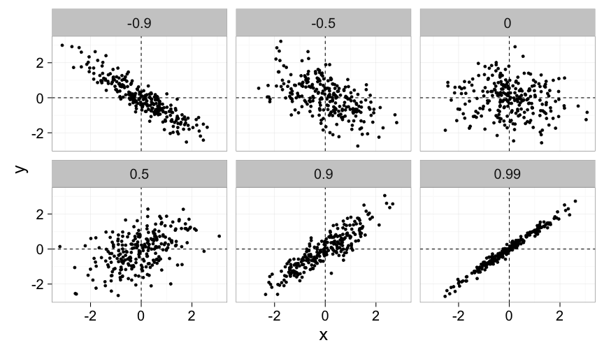

### Anscombe's quartet

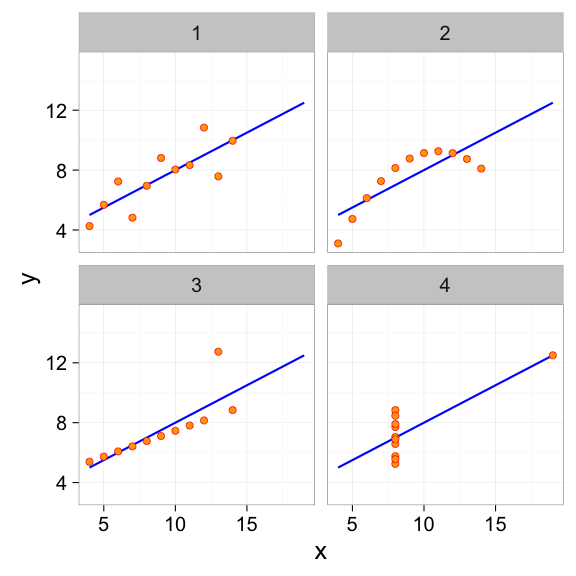

### Assessment

The following is a random variable.

```r
R <- sample_n( father.son, 100) %>% summarize(cor(fheight, sheight))
```

Use a Monte Carlo simulation to learn the distribution of the difference between `R` and the actual correlation. What is the SE of `R`? What is the distribution?

### Stratification

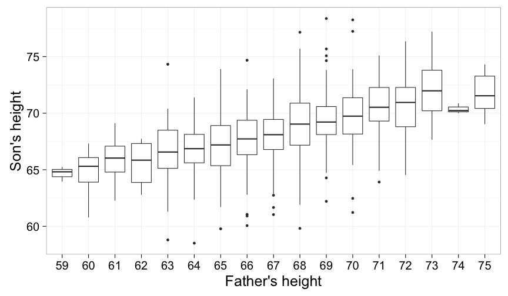

### Connection to Correlation

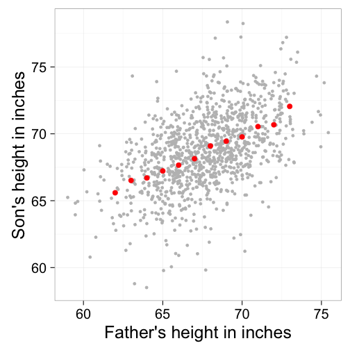

### Regression line

The points above define the regression line:

\[ \left( \frac{y_i-\mu_y}{\sigma_y} \right) = \rho \left( \frac{x_i-\mu_x}{\sigma_x} \right) \]

Note this is a line with \[ m = \rho \frac{\sigma_y}{\sigma_x} \]

\[ b=\mu_y - m \mu_x \]

### Regression line

If we standardize the data then the line has slope \( \rho \) and 0 intercept:

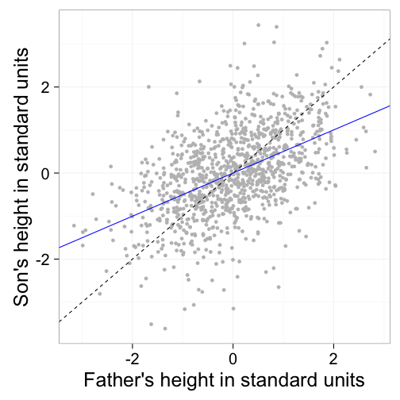

### Regression line

The regression line goes through the conditional averages

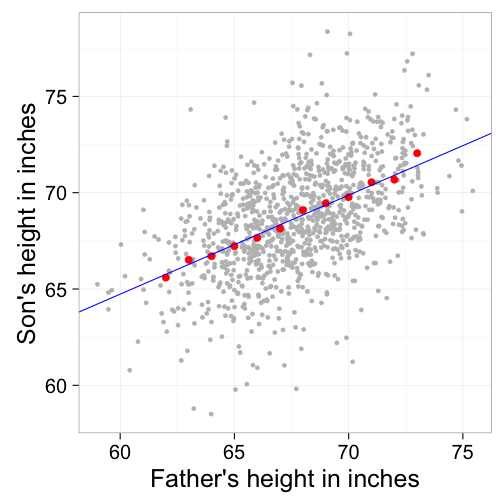

### Bivariate Normal

```r
n <- 250
cors <- c(-0.5,0,0.5,0.9)
dat <- lapply(cors,function(r)
  MASS::mvrnorm(n,c(0,0), matrix(c(1,r,r,1),2,2)))
```

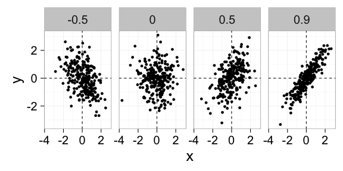

### Bivariate Normal

\[ f_{Y \mid X=x} \mbox{ is the conditional distribution and } \mbox{E}(Y \mid X=x) \mbox{ is the conditional expected value.} \]

We can derive this: \[ \mbox{E}(Y | X=x) = \mu_Y + \rho \frac{X-\mu_X}{\sigma_X}\sigma_Y \] Note that this is a line with slope \( \rho \frac{\sigma_Y}{\sigma_X} \).

And therefore: \[ \frac{\mbox{E}(Y \mid X=x) - \mu_Y}{\sigma_Y} = \rho \frac{x-\mu_X}{\sigma_X} \]

### Variance explained

The standard deviation of the *conditional* distribution described above is:

\[ \mbox{Var}(Y \mid X=x ) \sqrt{1-\rho^2} \sigma_y \]

### Linear Models

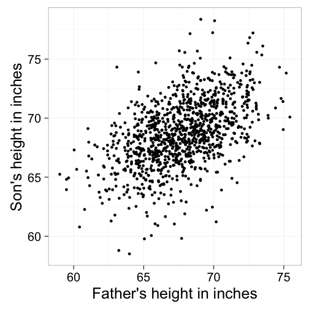

\[ Y_i = \beta_0 + \beta_1 x_i + \varepsilon_i, i=1,\dots,N \]

### Two regression Lines

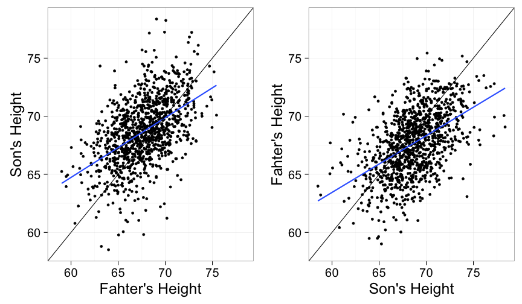

### Falling Object

Galileo's data motivates a linear model:

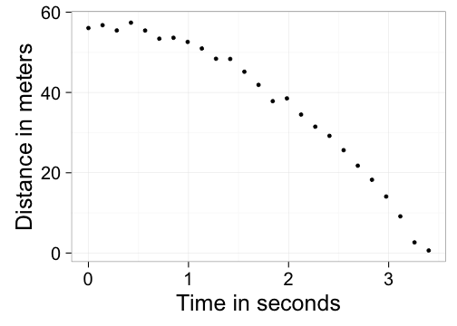

\[ Y_i = \beta_0 + \beta_1 x_i + \beta_2 x_i^2 + \varepsilon_i, i=1,\dots,n \]

### Least Squares

\[ \sum_{i=1}^n \left\{ Y_i - \left(\beta_0 + \sum_{j=1}^p \beta_j x_{i,j}\right)\right\}^2 \]

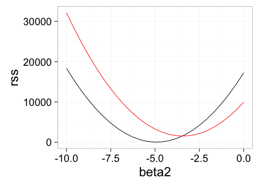

### The `lm` function

```r
fit <- falling_object %>% mutate(time_sq = time^2) %>% lm(y~time+time_sq, data=.)
summary(fit)$coef
```

```
            Estimate Std. Error t value Pr(>|t|)
(Intercept)     56.5       0.55  103.70  4.3e-31
time             0.5       0.74    0.68  5.1e-01
time_sq         -5.0       0.21  -23.88  3.2e-17
```

### HR and Runs

Let's Use the data in the `Team` table to explore the relationship between HR and runs per game in 1999. Let's make a plot to see if perhaps HR predicts runs.

```r
library(Lahman)
library(broom)
dat <- Teams %>%
  filter(yearID == 1999) %>%
  mutate(R = R / G, HR = HR / G)
```

### Linear Model

\[ R_i = \beta_0 + \beta_1 HR_i + \varepsilon_i, \hat{\beta}_1=1.7 \]

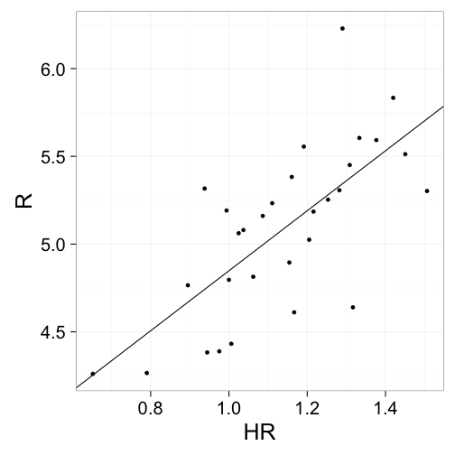

### Estimate is a Random Variable

Fit the model every year:

```r
res <- Teams %>% filter(yearID >= 1961) %>%
  mutate(R = R / G, HR = HR / G) %>%
  group_by(yearID) %>%
  do(tidy(lm(R ~ HR, data = .))) %>%
  filter(term == "HR")
sd(res$estimate)
```

```
[1] 0.33
```

### Estimate Properties

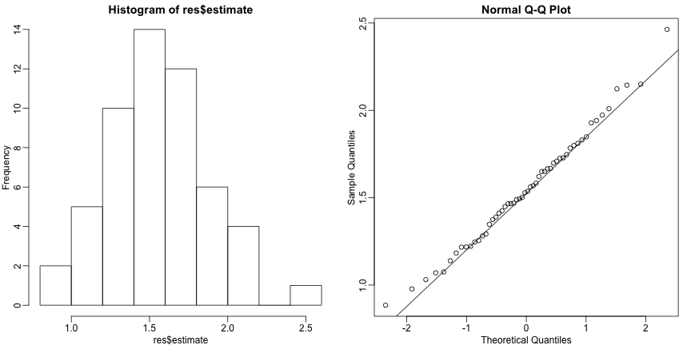

### CLT for regression

```r
fit <- dat  %>%
  lm(R ~ HR, data = .)

# either
res <- tidy(fit, conf.int = TRUE)
res %>%
  filter(term == "HR")
```

```
  term estimate std.error statistic p.value conf.low conf.high
1   HR      1.7      0.32       5.3 1.3e-05        1       2.4
```

### CLT for regression

```r
##or
res <- summary(fit)
res$coef[2,1] + c(-1,1)*qnorm(0.975)*res$coef[2,2]
```

```
[1] 1.1 2.3
```